# 7784 Skills: Programming in R

### Kirill Müller, Christoph Sax

### University of St. Gallen, 10.10.2019

# 10.10.: Transformation 2

# Topics for today

1. Admin: Final report, assignment, update syllabus

1. Review of assignment

1. Recap data tranformation with {dplyr}

1. Grouped operations in {dplyr}

1. Statistical transformations in {ggplot2}: bar chars, box plots, ...

# Admin

## Final report

- Groups freeze today 9:00 PM CEST, team leader assigned randomly

- We will create a repository that is private to your team

# Course Syllabus

- Part 1: Data Transformation ✓

- Part 2: Modeling

- Part 3: Advanced Topics

# Part 1: Data Transformation (Kirill)

- 26.9.: Visualization and reporting ✓

- 3.10.: Transforming data I ✓

- **10.10.: Transforming data II** [Due: groups and report topic]

# Part 2: Modeling (Christoph)

- 17.10.: R Base [Due: assignment 1]

- 24.10.: Statistical models

- 14.11.: Communicating models

# Part 3: Advanced Topics (preliminary)

- **21.11.: Transforming data III** [Due: assignment 2]

- 28.11.: Data Sources

- **5.12.: Statistical models II**

- 12.12.: Workflow Review  [Due: assignment 3]

- 19.12.: Workflow review II [Due: report]

# Assignments

- Hand-in: `*.R` and `*.Rmd` files

- `README.md` should explain which files to run

- GitHub Pages not required, but still a good exercise

- See `index.Rmd` and `_site.yml` in https://github.com/unisg-progr-19/hw1-krlmlr
      for automation example

- Copy these files into your repository to enable this feature

- Please **archive** all unneeded repositories

# Ensure repeatability

All code should be **self-contained** and **reproducible**

## Run in a clean R session

- Ctrl + Shift + F10 to restart R
- Ctrl + Shift + K to "knit" document

## Always produce the same results

- Set random seed with `set.seed()`

# Separating scripts and rmarkdown

## Script

- perform computation, can be long-running

## Report

- display results, should run fast

# Separating scripts and rmarkdown

## Save results to a file in `*.R`

```r
saveRDS(
  result,
  here("results/file.rds")
)
```

## Load results from file in `*.Rmd`

```r
result <- readRDS(
  here("results/file.rds")
)
```

# Transformation

# Filtering functions

## Compute one predicate (`TRUE` or `FALSE`) per row

- `==`, `!=`, `<`, `>`, `<=`, `>=`, ... -- see `?"=="`

- `=` is not a comparison operator!

- `near()`

- `between()`, `%in%`

- `is.na()` -- missing values

# Mutating functions

## Compute one value per row

- `+`, `-`, `*`, `/`, ... -- see `?"+"`

- `sin()`, `cos()`, ...

- `lead()` and `lag()` -- look at next or previous row

- `cumsum()`, `cumprod()`, ... -- look at all previous rows

- `if_else()`, `recode()` -- recoding

- `==`, `is.na()` -- compute a `TRUE` or `FALSE` value

- `x / sum(x)` -- look at all rows

# Summary functions

## Compute one overall result

- `sum(na.rm = ...)`, `prod()`, `mean()`, `median()`

- `sd()`, `IQR()`, `mad()`

- `min()`, `quantile(0.75)`, `max()`

- `n()`

- `sum()` and `mean()` for predicates -- counts and shares

- `first()`, `last()`, `nth()` -- selection by position

# Demo: [`27-summarize.R`](https://github.com/krlmlr/vistransrep-proj/blob/master/script/27-summarize.R)

# Summary plots

# {ggplot2}: histogram

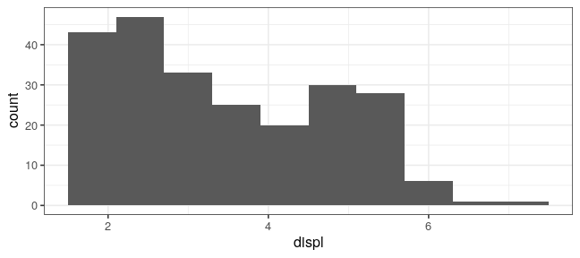

```r
mpg %>%
  ggplot(aes(x = displ)) +
  geom_histogram(bins = 10)
```

# {ggplot2}: smoothing lines

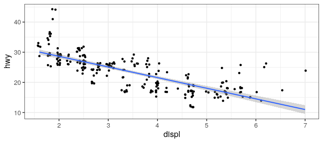

```r
mpg %>%
  ggplot(aes(x = displ, y = hwy)) +
  geom_jitter() +
  geom_smooth(method = "lm", formula = y ~ x)
```

# {ggplot2}: box plots

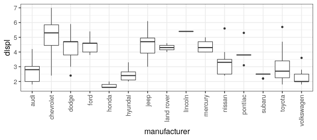

```r
mpg %>%
  ggplot(aes(x = manufacturer, y = displ)) +
  geom_boxplot() +
  ggpubr::rotate_x_text()
```

# {ggplot2}: statistical tranformations

```r
# When plotting
data %>%
  ggplot(aes(...)) +
  geom_...(aes(...), stat = ..., ...)

# Manually
data %>%
  group_by(...) %>%
  summarize(...) %>%
  ungroup() %>%
  ggplot(aes(...)) +
  geom_...(aes(...), ...)
```

# {ggplot2}: bar charts

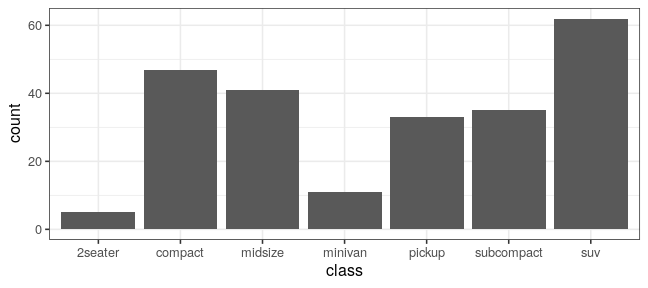

```r
mpg %>%
  # use original data
  ggplot(aes(x = class)) +
  geom_bar()
```

# {ggplot2}: bar charts

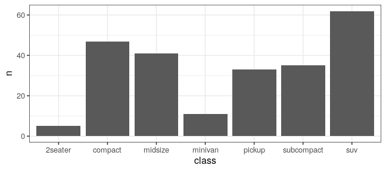

```r
mpg %>%
* count(class) %>%
  ggplot(aes(x = class, y = n)) +
  geom_col()
```

# Extensions

http://www.ggplot2-exts.org/gallery/